# Project-Ensemble Techniques - Term Deposit Subscription Prediction_06.19.2020

##### Step-4: Cut into bins for continuous variables for smoothing data

Step-4.1: Binning balance and replacing with integer labels

```python
# binning balance takes care of negative values

cut_labels_balance = [1,2,3,4,5,6,7,8,9,10,11,12]

dfTermDeposit['balance'] = pd.cut(dfTermDeposit['balance'], bins=np.linspace(-10000, 110000, 13),
                                  labels=cut_labels_balance)
```

```python
# checking that the balance values are correctly binned.

dfTermDeposit['balance'].value_counts().sort_index(ascending=True)
```

```
1      7280
2     37102
3       636
4       141
5        24
6        10
7        10
8         3
9         1
10        2
11        1
12        1
Name: balance, dtype: int64
```

Step-4.2: Binning duration and replacing with integer labels

```python
# binning duration to take care of skewness

cut_labels_duration = [1,2,3,4,5,6,7,8,9,10]

dfTermDeposit['duration'] = pd.cut(dfTermDeposit['duration'], bins=np.linspace(0, 5000, 11),
                                   labels=cut_labels_duration)
```

```python
# checking that the duration values are correctly binned

dfTermDeposit['duration'].unique()
```

```
[1, 2, 4, 3, 5, 7, NaN, 6, 8, 10]
Categories (9, int64): [1 < 2 < 3 < 4 ... 6 < 7 < 8 < 10]
```

```python
# O is imputed as NaN as it is not included in the first bin. use fillna = 1 to rectify

dfTermDeposit['duration'].fillna(1,inplace=True)
```

```python
# checking if NaN and NA still exist in the dataframe

dfTermDeposit.isna().sum()
```

```
age          0
job          0
marital      0
education    0
default      0
balance      0
housing      0
loan         0
contact      0
day          0
month        0
duration     0
campaign     0
pdays        0
previous     0
poutcome     0
Target       0
dtype: int64
```

```python
# checking that the duration values are correctly binned.

dfTermDeposit['duration'].value_counts().sort_index(ascending=True)
```

```
1     39840
2      4313
3       831
4       168
5        36
6         9
7        11
8         2
9         0
10        1
Name: duration, dtype: int64
```

Step-4.3: Binning pdays and replacing with integer labels

```python
# binning pdays to take care of negative values
# -1 is binned with label 1 because on checking the values against 0 from the previous column
# they have the same values 36954 earlier. so, -1 means person has not been contacted at all.

cut_labels_pdays = [1,2,3,4,5,6,7,8,9,10]

dfTermDeposit['pdays'] = pd.cut(dfTermDeposit['pdays'], bins=np.linspace(-1, 1000, 11), labels=cut_labels_pdays)
```

```python
# checking that the duration values are correctly binned

dfTermDeposit['pdays'].unique()
```

```
[NaN, 2, 1, 3, 4, 5, 6, 7, 8, 9]
Categories (9, int64): [1 < 2 < 3 < 4 ... 6 < 7 < 8 < 9]
```

```python
# -1 is imputed as NaN as it is not included in the first bin. use fillna = 1 to rectify

dfTermDeposit['pdays'].fillna(1,inplace=True)
```

```python
# checking if NaN and NA still exist in the dataframe

dfTermDeposit.isna().sum()
```

```
age          0
job          0
marital      0
education    0
default      0
balance      0
housing      0
loan         0
contact      0
day          0
month        0
duration     0
campaign     0
pdays        0
previous     0
poutcome     0
Target       0
dtype: int64
```

```python
# check for the resulting dataframe

dfTermDeposit.head()
```

|  | age | job | marital | education | default | balance | housing | loan | contact | day | month | duration | campaign | pdays | previous | poutcome | Target |
| --- | --- | --- | --- | --- | --- | --- | --- | --- | --- | --- | --- | --- | --- | --- | --- | --- | --- |
| 0 | 58 | management | 2 | 3 | 0 | 2 | 1 | 0 | unknown | 5 | 5 | 1 | 1 | 1 | 0 | unknown | 0 |
| 1 | 44 | technician | 1 | 2 | 0 | 2 | 1 | 0 | unknown | 5 | 5 | 1 | 1 | 1 | 0 | unknown | 0 |
| 2 | 33 | entrepreneur | 2 | 2 | 0 | 2 | 1 | 1 | unknown | 5 | 5 | 1 | 1 | 1 | 0 | unknown | 0 |
| 3 | 47 | blue-collar | 2 | 4 | 0 | 2 | 1 | 0 | unknown | 5 | 5 | 1 | 1 | 1 | 0 | unknown | 0 |
| 4 | 33 | unknown | 1 | 4 | 0 | 2 | 0 | 0 | unknown | 5 | 5 | 1 | 1 | 1 | 0 | unknown | 0 |

##### Step-5: Check that the data type of features are all int or float

```python
# check for the datatype of the features

dfTermDeposit.info()
```

```
<class 'pandas.core.frame.DataFrame'>
RangeIndex: 45211 entries, 0 to 45210
Data columns (total 17 columns):
 #   Column     Non-Null Count  Dtype
---  ------     --------------  -----
 0   age        45211 non-null  int64
 1   job        45211 non-null  category
 2   marital    45211 non-null  int64
 3   education  45211 non-null  int64
 4   default    45211 non-null  int64
 5   balance    45211 non-null  category
 6   housing    45211 non-null  int64
 7   loan       45211 non-null  int64
 8   contact    45211 non-null  category
 9   day        45211 non-null  int64
 10  month      45211 non-null  int64
 11  duration   45211 non-null  category
 12  campaign   45211 non-null  int64
 13  pdays      45211 non-null  category
 14  previous   45211 non-null  int64
 15  poutcome   45211 non-null  category
 16  Target     45211 non-null  int64
dtypes: category(6), int64(11)
memory usage: 4.1 MB
```

```python
# change the datatype of balance, duration and pdays as int

dfTermDeposit = dfTermDeposit.astype({'balance':int,'duration':int,'pdays':int})
```

```python
# check that the datatypes have been correcly changed.

dfTermDeposit.info()
```

```
<class 'pandas.core.frame.DataFrame'>
RangeIndex: 45211 entries, 0 to 45210
Data columns (total 17 columns):
 #   Column     Non-Null Count  Dtype
---  ------     --------------  -----
 0   age        45211 non-null  int64
 1   job        45211 non-null  category
 2   marital    45211 non-null  int64
 3   education  45211 non-null  int64
 4   default    45211 non-null  int64
 5   balance    45211 non-null  int64
 6   housing    45211 non-null  int64
 7   loan       45211 non-null  int64
 8   contact    45211 non-null  category
 9   day        45211 non-null  int64
 10  month      45211 non-null  int64
 11  duration   45211 non-null  int64
 12  campaign   45211 non-null  int64
 13  pdays      45211 non-null  int64
 14  previous   45211 non-null  int64
 15  poutcome   45211 non-null  category
 16  Target     45211 non-null  int64
dtypes: category(3), int64(14)
memory usage: 5.0 MB
```

```python
# check the statistical values of the base model dfTermDeposit

dfTermDeposit.describe().T
```

|  | count | mean | std | min | 25% | 50% | 75% | max |
| --- | --- | --- | --- | --- | --- | --- | --- | --- |
| age | 45211.0 | 40.936210 | 10.618762 | 18.0 | 33.0 | 39.0 | 48.0 | 95.0 |
| marital | 45211.0 | 1.832275 | 0.608230 | 1.0 | 1.0 | 2.0 | 2.0 | 3.0 |
| education | 45211.0 | 2.224813 | 0.747997 | 1.0 | 2.0 | 2.0 | 3.0 | 4.0 |
| default | 45211.0 | 0.018027 | 0.133049 | 0.0 | 0.0 | 0.0 | 0.0 | 1.0 |
| balance | 45211.0 | 1.864192 | 0.439635 | 1.0 | 2.0 | 2.0 | 2.0 | 12.0 |
| housing | 45211.0 | 0.555838 | 0.496878 | 0.0 | 0.0 | 1.0 | 1.0 | 1.0 |
| loan | 45211.0 | 0.160226 | 0.366820 | 0.0 | 0.0 | 0.0 | 0.0 | 1.0 |
| day | 45211.0 | 15.806419 | 8.322476 | 1.0 | 8.0 | 16.0 | 21.0 | 31.0 |
| month | 45211.0 | 6.144655 | 2.408034 | 1.0 | 5.0 | 6.0 | 8.0 | 12.0 |
| duration | 45211.0 | 1.149455 | 0.458765 | 1.0 | 1.0 | 1.0 | 1.0 | 10.0 |
| campaign | 45211.0 | 2.763841 | 3.098021 | 1.0 | 1.0 | 2.0 | 3.0 | 63.0 |
| pdays | 45211.0 | 1.304240 | 0.825792 | 1.0 | 1.0 | 1.0 | 1.0 | 9.0 |
| previous | 45211.0 | 0.580323 | 2.303441 | 0.0 | 0.0 | 0.0 | 0.0 | 275.0 |
| Target | 45211.0 | 0.116985 | 0.321406 | 0.0 | 0.0 | 0.0 | 0.0 | 1.0 |

### Based data model is "dfTermDeposit"

### 2.2 Scaling and Normalization

```python
# final dataframe after data clean up

dfTermDeposit.head()
```

|  | age | job | marital | education | default | balance | housing | loan | contact | day | month | duration | campaign | pdays | previous | poutcome | Target |
| --- | --- | --- | --- | --- | --- | --- | --- | --- | --- | --- | --- | --- | --- | --- | --- | --- | --- |
| 0 | 58 | management | 2 | 3 | 0 | 2 | 1 | 0 | unknown | 5 | 5 | 1 | 1 | 1 | 0 | unknown | 0 |
| 1 | 44 | technician | 1 | 2 | 0 | 2 | 1 | 0 | unknown | 5 | 5 | 1 | 1 | 1 | 0 | unknown | 0 |
| 2 | 33 | entrepreneur | 2 | 2 | 0 | 2 | 1 | 1 | unknown | 5 | 5 | 1 | 1 | 1 | 0 | unknown | 0 |
| 3 | 47 | blue-collar | 2 | 4 | 0 | 2 | 1 | 0 | unknown | 5 | 5 | 1 | 1 | 1 | 0 | unknown | 0 |
| 4 | 33 | unknown | 1 | 4 | 0 | 2 | 0 | 0 | unknown | 5 | 5 | 1 | 1 | 1 | 0 | unknown | 0 |

```python
# check the skewness of the dataframe

dfTermDeposit.skew()
```

```
age           0.684818
marital       0.102826
education     0.197275
default       7.245375
balance       1.155656
housing      -0.224766
loan          1.852617
day           0.093079
month         0.242842
duration      4.192384
campaign      4.898650
pdays         3.089162
previous     41.846454
Target        2.383480
dtype: float64
```

```python
# correlation between attributes

corr = dfTermDeposit.corr() # assigning variable corr as the correlation function output

corr
```

|  | age | marital | education | default | balance | housing | loan | day | month | duration | campaign | pdays | previous | Target |
| --- | --- | --- | --- | --- | --- | --- | --- | --- | --- | --- | --- | --- | --- | --- |
| age | 1.000000 | 0.403240 | -0.106807 | -0.017879 | 0.033632 | -0.185513 | -0.015655 | -0.009120 | 0.092903 | 0.002352 | 0.004760 | -0.034809 | 0.001288 | 0.025155 |
| marital | 0.403240 | 1.000000 | -0.108576 | 0.007023 | -0.040932 | 0.016096 | 0.046893 | 0.005261 | 0.050938 | -0.005999 | 0.008994 | -0.016996 | -0.014973 | -0.045588 |
| education | -0.106807 | -0.108576 | 1.000000 | -0.010718 | 0.049327 | -0.090790 | -0.048574 | 0.022671 | 0.054729 | 0.002639 | 0.006255 | -0.010861 | 0.017570 | 0.066241 |
| default | -0.017879 | 0.007023 | -0.010718 | 1.000000 | -0.168017 | -0.006025 | 0.077234 | 0.009424 | 0.014989 | -0.009714 | 0.016822 | -0.025156 | -0.018329 | -0.022419 |
| balance | 0.033632 | -0.040932 | 0.049327 | -0.168017 | 1.000000 | -0.055808 | -0.100291 | -0.026337 | 0.022485 | 0.007529 | -0.029590 | 0.022240 | 0.028858 | 0.063286 |
| housing | -0.185513 | 0.016096 | -0.090790 | -0.006025 | -0.055808 | 1.000000 | 0.041323 | -0.027982 | -0.173887 | 0.006618 | -0.023599 | 0.140021 | 0.037076 | -0.139173 |
| loan | -0.015655 | 0.046893 | -0.048574 | 0.077234 | -0.100291 | 0.041323 | 1.000000 | 0.011370 | 0.021638 | -0.006920 | 0.009980 | -0.015109 | -0.011043 | -0.068185 |
| day | -0.009120 | 0.005261 | 0.022671 | 0.009424 | -0.026337 | -0.027982 | 0.011370 | 1.000000 | 0.101989 | -0.005677 | 0.162490 | -0.088894 | -0.051710 | -0.028348 |
| month | 0.092903 | 0.050938 | 0.054729 | 0.014989 | 0.022485 | -0.173887 | 0.021638 | 0.101989 | 1.000000 | 0.003695 | 0.054868 | -0.121908 | -0.035600 | 0.018717 |
| duration | 0.002352 | -0.005999 | 0.002639 | -0.009714 | 0.007529 | 0.006618 | -0.006920 | -0.005677 | 0.003695 | 1.000000 | -0.019738 | -0.012013 | -0.004129 | 0.346004 |
| campaign | 0.004760 | 0.008994 | 0.006255 | 0.016822 | -0.029590 | -0.023599 | 0.009980 | 0.162490 | 0.054868 | -0.019738 | 1.000000 | -0.077352 | -0.032855 | -0.073172 |
| pdays | -0.034809 | -0.016996 | -0.010861 | -0.025156 | 0.022240 | 0.140021 | -0.015109 | -0.088894 | -0.121908 | -0.012013 | -0.077352 | 1.000000 | 0.402115 | 0.064076 |
| previous | 0.001288 | -0.014973 | 0.017570 | -0.018329 | 0.028858 | 0.037076 | -0.011043 | -0.051710 | -0.035600 | -0.004129 | -0.032855 | 0.402115 | 1.000000 | 0.093236 |
| Target | 0.025155 | -0.045588 | 0.066241 | -0.022419 | 0.063286 | -0.139173 | -0.068185 | -0.028348 | 0.018717 | 0.346004 | -0.073172 | 0.064076 | 0.093236 | 1.000000 |

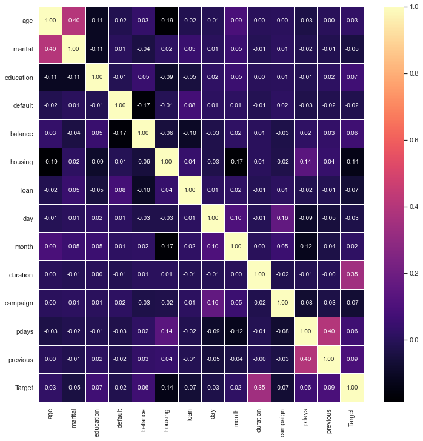

```python
# plotting heatmap for the correlation

plt.figure(figsize=(12,12))

sns.heatmap(corr, annot=True, linewidth=0.05, fmt='0.2f',cmap ='magma');
plt.show()
```

1. Since the Machine Learning models to be used are Logistic regression and Decision tree, I am not scaling and Normalizing the dataset.

### 2.2.1 OneHotEncoding for the remaining 3 categorical features job, contact, poutcome

```python
# onehotcoding for the dataframe

oneHotCols = ['job','contact','poutcome']

dfTermDeposit = pd.get_dummies(dfTermDeposit, columns=oneHotCols) # using get_dummies function
```

```python
# do a final check of dataframe after onehotencoding

dfTermDeposit.head()
```

|  | age | marital | education | default | balance | housing | loan | day | month | duration | ... | job_technician | job_unemployed | job_unknown | contact_cellular | contact_telephone | contact_unknown | poutcome_failure | poutcome_other | poutcome_success | poutcome_unknown |
| --- | --- | --- | --- | --- | --- | --- | --- | --- | --- | --- | --- | --- | --- | --- | --- | --- | --- | --- | --- | --- | --- |
| 0 | 58 | 2 | 3 | 0 | 2 | 1 | 0 | 5 | 5 | 1 | ... | 0 | 0 | 0 | 0 | 0 | 1 | 0 | 0 | 0 | 1 |
| 1 | 44 | 1 | 2 | 0 | 2 | 1 | 0 | 5 | 5 | 1 | ... | 1 | 0 | 0 | 0 | 0 | 1 | 0 | 0 | 0 | 1 |
| 2 | 33 | 2 | 2 | 0 | 2 | 1 | 1 | 5 | 5 | 1 | ... | 0 | 0 | 0 | 0 | 0 | 1 | 0 | 0 | 0 | 1 |
| 3 | 47 | 2 | 4 | 0 | 2 | 1 | 0 | 5 | 5 | 1 | ... | 0 | 0 | 0 | 0 | 0 | 1 | 0 | 0 | 0 | 1 |
| 4 | 33 | 1 | 4 | 0 | 2 | 0 | 0 | 5 | 5 | 1 | ... | 0 | 0 | 1 | 0 | 0 | 1 | 0 | 0 | 0 | 1 |

5 rows × 33 columns

```python
# check that the dataframe columns are all in the same datatype

dfTermDeposit.info() # the dataframe columns are in the same data type
```

```
<class 'pandas.core.frame.DataFrame'>
RangeIndex: 45211 entries, 0 to 45210
Data columns (total 33 columns):
 #   Column             Non-Null Count  Dtype
---  ------             --------------  -----
 0   age                45211 non-null  int64
 1   marital            45211 non-null  int64
 2   education          45211 non-null  int64
 3   default            45211 non-null  int64
 4   balance            45211 non-null  int64
 5   housing            45211 non-null  int64
 6   loan               45211 non-null  int64
 7   day                45211 non-null  int64
 8   month              45211 non-null  int64
 9   duration           45211 non-null  int64
```

[output cut: 25 more lines]

### 2.3 Training/Test set split ratio 70:30

### 2.3.1 Preparing data for Logistic regression model

```python
# dropped job_unknown, contact_unknown, poutcome_unknown from the dataframe as they don't add value to the model

dfTermDeposit_LR = dfTermDeposit.drop(
                                      ['job_unknown','contact_unknown','poutcome_unknown'], axis=1)
# dataframe for logistic regression
```

```python
# creating a new dataframe from the original dataframe for model training and testing

dfTermDeposit_LR.head()
```

|  | age | marital | education | default | balance | housing | loan | day | month | duration | ... | job_self-employed | job_services | job_student | job_technician | job_unemployed | contact_cellular | contact_telephone | poutcome_failure | poutcome_other | poutcome_success |
| --- | --- | --- | --- | --- | --- | --- | --- | --- | --- | --- | --- | --- | --- | --- | --- | --- | --- | --- | --- | --- | --- |
| 0 | 58 | 2 | 3 | 0 | 2 | 1 | 0 | 5 | 5 | 1 | ... | 0 | 0 | 0 | 0 | 0 | 0 | 0 | 0 | 0 | 0 |
| 1 | 44 | 1 | 2 | 0 | 2 | 1 | 0 | 5 | 5 | 1 | ... | 0 | 0 | 0 | 1 | 0 | 0 | 0 | 0 | 0 | 0 |
| 2 | 33 | 2 | 2 | 0 | 2 | 1 | 1 | 5 | 5 | 1 | ... | 0 | 0 | 0 | 0 | 0 | 0 | 0 | 0 | 0 | 0 |
| 3 | 47 | 2 | 4 | 0 | 2 | 1 | 0 | 5 | 5 | 1 | ... | 0 | 0 | 0 | 0 | 0 | 0 | 0 | 0 | 0 | 0 |
| 4 | 33 | 1 | 4 | 0 | 2 | 0 | 0 | 5 | 5 | 1 | ... | 0 | 0 | 0 | 0 | 0 | 0 | 0 | 0 | 0 | 0 |

5 rows × 30 columns

```python
# import the train_test_split function from scikit-learn

from sklearn.model_selection import train_test_split

# dividing the data set in to dependent and independent variables
# all independent variables

x1 = dfTermDeposit_LR.drop(['Target'],axis=1)

# Term Deposit column which is dependent variable

y1 = dfTermDeposit_LR[['Target']]
```

```python
# splitting the data into ratio 70:30

x1_train, x1_test, y1_train, y1_test = train_test_split(x1,y1,test_size=0.30, random_state=1)

x1_train.shape, x1_test.shape, y1_train.shape, y1_test.shape
```

```
((31647, 29), (13564, 29), (31647, 1), (13564, 1))
```

### 2.3.2 Preparing data for Decision Tree model

```python
# dataframe for decision tree and ensemble models

dfTermDeposit_DT = dfTermDeposit.copy()
```

```python
# dividing the data set in to dependent and independent variables
# all independent variables

x2 = dfTermDeposit_DT.drop(['Target'],axis=1)

# Term Deposit column which is dependent variable

y2 = dfTermDeposit_DT[['Target']]
```

```python
# splitting the data into ratio 70:30

x2_train, x2_test, y2_train, y2_test = train_test_split(x2,y2,test_size=0.30, random_state=1)

x2_train.shape, x2_test.shape, y2_train.shape, y2_test.shape
```

```
((31647, 32), (13564, 32), (31647, 1), (13564, 1))
```

## Deliverable – 3 (create the ensemble model) – (30 marks)

#### 3.1. First create models using Logistic Regression and Decision Tree algorithm. Note the model performance by using different matrices. Use confusion matrix to evaluate class level metrics i.e. Precision/Recall. Also reflect the accuracy and F1 score of the model. (10 marks)

### 3.1.1 Logistic Regression ML Base Model

###### Logistic Regression model building

1. Train the model and then test it.
2. Calculate Confusion Matrix, Recall, Precision, AUC, F1 Score
3. Plot the Confusion Matrix in the form of heat map
4. Plot the AUC curve </font>

```python
# building the logistic regression model and training the model

from sklearn.linear_model import LogisticRegression

logreg = LogisticRegression(random_state=42)
logreg.fit(x1_train,y1_train)
```

```
LogisticRegression(C=1.0, class_weight=None, dual=False, fit_intercept=True,
                   intercept_scaling=1, l1_ratio=None, max_iter=100,
                   multi_class='auto', n_jobs=None, penalty='l2',
                   random_state=42, solver='lbfgs', tol=0.0001, verbose=0,
                   warm_start=False)
```

```python
# predict the independent variable

y1_predict = logreg.predict(x1_test)
```

#### 1. Confusion Matrix for base logistic regression Model

```python
# importing the metrics from scikit-learn for the model metrics

from sklearn.metrics import confusion_matrix, recall_score, precision_score, f1_score, roc_auc_score, accuracy_score

from sklearn import metrics

cm = metrics.confusion_matrix(y1_test,y1_predict) # print confusion matrix

print(cm)
```

```
[[11740   273]
 [ 1110   441]]
```

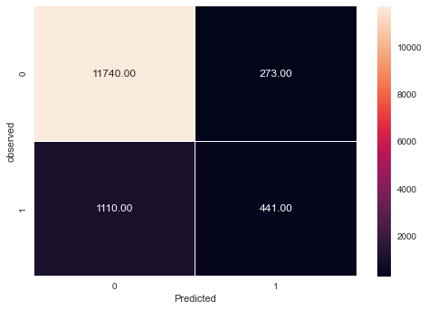

```python
# plot the confusion matrix in terms of heatmap for better visualization.

def draw_cm(actual,predicted):
    cm = confusion_matrix(actual,predicted)
    sns.heatmap(cm,annot=True, linewidth=0.05, fmt='.2f', xticklabels=[0,1], yticklabels=[0,1])
    plt.ylabel('observed')
    plt.xlabel('Predicted')
    plt.show()

# pass parameters in draw_cm function to plot the heatmap.

draw_cm(y1_test,y1_predict)
```

```python
# True Positive (TP) = 441
# True Negative (TN) = 11740
# False Positive (FP) = 273
# False Negative(FN) = 1110
```

#### 2. Metrics for base logistic regression Model

```python
# comparing training to testing score for base logistic regression model

print('Training Score:',logreg.score(x1_train,y1_train))
print('')
print('Testing Score:',logreg.score(x1_test,y1_test))
```

```
Training Score: 0.8961986918191298

Testing Score: 0.8980389265703332
```

```python
# Logistic regression metrics

logreg_accuracy = accuracy_score(y1_test, y1_predict)
logreg_recall = recall_score(y1_test, y1_predict)
logreg_f1 = f1_score(y1_test,y1_predict)
logreg_precision = precision_score(y1_test,y1_predict)
logreg_AUC = roc_auc_score(y1_test,y1_predict)

print('Accuracy:',logreg_accuracy)
print()
print('Recall:',logreg_recall)
print()
print('F1 Score:',logreg_f1)
print()
print('Precision:',logreg_precision)
print()
print('AUC:',logreg_AUC)
```

```
Accuracy: 0.8980389265703332

Recall: 0.28433268858800775

F1 Score: 0.3894039735099338

Precision: 0.6176470588235294

AUC: 0.6308036538752907
```

```python
# saving the metrics for base logistic regression in a dataframe

dfModelComparison = pd.DataFrame({'Model':['Base Logistic Regression'],'Accuracy':logreg_accuracy,
                                  'Recall':logreg_recall,'F1 Score':logreg_f1,'Precision':logreg_precision,
                                  'AUC':logreg_AUC})

dfModelComparison.head() # is the final dataframe for comparison of all model performance metrics
```

|  | Model | Accuracy | Recall | F1 Score | Precision | AUC |
| --- | --- | --- | --- | --- | --- | --- |
| 0 | Base Logistic Regression | 0.898039 | 0.284333 | 0.389404 | 0.617647 | 0.630804 |

#### 3. Visualization of Metrics for Logistic Regression Model

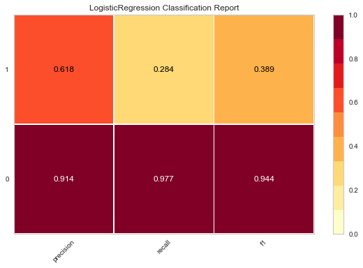

```python
# visualization of confusion matrix for base logistic regression using yellowbrick package

from yellowbrick.classifier import ClassificationReport, ROCAUC
viz = ClassificationReport(LogisticRegression(random_state=42))
viz.fit(x1_train,y1_train)
viz.score(x1_test,y1_test)
viz.show();
```

1. The visualization shows that the precision is about 61%
2. Recall is about 28%
3. Number of total people subscribing to Term Deposit is 1551
4. Number of people subscribing to the Term Deposit successfully predicted by model is 441
5. Number of people subscribing to the Term Deposit not predicted by the model is 1110 </font>

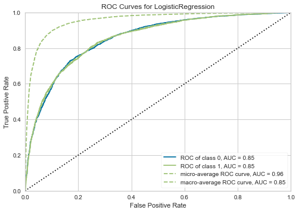

```python
# plotting area under the AUC curve

roc = ROCAUC(LogisticRegression(random_state=42))
roc.fit(x1_train,y1_train)
roc.score(x1_test,y1_test)
roc.show();
```

### 3.1.2 Performance Tuned Logistic Regression ML Model

```python
# fetch the parameters of the logistic model from the first iteration to analyze how to improve the model

logreg.get_params()
```

```
{'C': 1.0,
 'class_weight': None,
 'dual': False,
 'fit_intercept': True,
 'intercept_scaling': 1,
 'l1_ratio': None,
 'max_iter': 100,
 'multi_class': 'auto',
 'n_jobs': None,
 'penalty': 'l2',
 'random_state': 42,
 'solver': 'lbfgs',
 'tol': 0.0001,
 'verbose': 0,
 'warm_start': False}
```

```python
# from scikit-learn use the GridSearchCV library to find out the optimum parameters for logistic model

from sklearn.model_selection import GridSearchCV

param_grid = [{'solver': ['newton-cg','lbfgs','liblinear','sag','saga'], 'C': [0.001,0.01,0.1,0.25,0.5,0.75,1],
              'class_weight':['balanced'], 'penalty':['l2']}]


grid_search = GridSearchCV(LogisticRegression(),param_grid,cv=5, verbose=0)
grid_search.fit(x1_train,y1_train)
```

```
GridSearchCV(cv=5, error_score=nan,
             estimator=LogisticRegression(C=1.0, class_weight=None, dual=False,
                                          fit_intercept=True,
                                          intercept_scaling=1, l1_ratio=None,
                                          max_iter=100, multi_class='auto',
                                          n_jobs=None, penalty='l2',
                                          random_state=None, solver='lbfgs',
                                          tol=0.0001, verbose=0,
                                          warm_start=False),
             iid='deprecated', n_jobs=None,
             param_grid=[{'C': [0.001, 0.01, 0.1, 0.25, 0.5, 0.75, 1],
                          'class_weight': ['balanced'], 'penalty': ['l2'],
                          'solver': ['newton-cg', 'lbfgs', 'liblinear', 'sag',
                                     'saga']}],
             pre_dispatch='2*n_jobs', refit=True, return_train_score=False,
             scoring=None, verbose=0)
```

```python
# Multiple interation are run and provides the best estimator of the logistic regression.

grid_search.best_estimator_
```

```
LogisticRegression(C=0.75, class_weight='balanced', dual=False,
                   fit_intercept=True, intercept_scaling=1, l1_ratio=None,
                   max_iter=100, multi_class='auto', n_jobs=None, penalty='l2',
                   random_state=None, solver='newton-cg', tol=0.0001, verbose=0,
                   warm_start=False)
```

```python
# best logistic model generated by changing the parameters

bestModelLR = LogisticRegression(C=0.75, class_weight='balanced', dual=False,
                   fit_intercept=True, intercept_scaling=1, l1_ratio=None,
                   max_iter=100, multi_class='auto', n_jobs=None, penalty='l2',
                   random_state=None, solver='newton-cg', tol=0.0001, verbose=0,
                   warm_start=False)

bestModelLR.fit(x1_train, y1_train)
y1_predict_best = bestModelLR.predict(x1_test)
```

#### 1. Confusion Matrix for Tuned logistic regression Model

```python
# print confusion matrix

cm = metrics.confusion_matrix(y1_test,y1_predict_best)

print(cm)
```

```
[[9949 2064]
 [ 397 1154]]
```

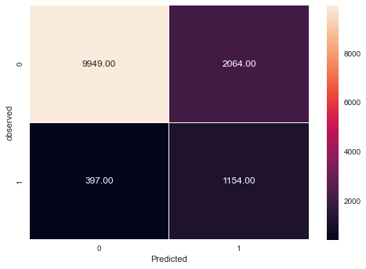

```python
# plot the confusion matrix in terms of heatmap for better visualization.
# pass parameters in draw_cm function to plot the heatmap.

draw_cm(y1_test,y1_predict_best)
```

```python
# True Positive (TP) = 1154
# True Negative (TN) = 9949
# False Positive (FP) = 2064
# False Negative(FN) = 397
```

#### 2. Metrics for Tuned logistic regression Model

```python
# comparing training to testing score for tuned logistic regression model

print('Training Score:',bestModelLR.score(x1_train,y1_train))
print('')
print('Testing Score:',bestModelLR.score(x1_test,y1_test))
```

```
Training Score: 0.8239327582393275

Testing Score: 0.8185638454733117
```

```python
# Tuned Logistic regression performance metrics

tuned_logreg_accuracy = accuracy_score(y1_test, y1_predict_best)
tuned_logreg_recall = recall_score(y1_test, y1_predict_best)
tuned_logreg_f1 = f1_score(y1_test,y1_predict_best)
tuned_logreg_precision = precision_score(y1_test,y1_predict_best)
tuned_logreg_AUC = roc_auc_score(y1_test,y1_predict_best)

print('Accuracy:', tuned_logreg_accuracy)
print()
print('Recall:', tuned_logreg_recall)
print()
print('F1 Score:', tuned_logreg_f1)
print()
print('Precision:', tuned_logreg_precision)
print()
print('AUC:', tuned_logreg_AUC )
```

```
Accuracy: 0.8185638454733117

Recall: 0.7440361057382334

F1 Score: 0.48395890123715657

Precision: 0.3586078309509012

AUC: 0.7861111187144509
```

```python
# saving the metrics for base logistic regression in a dataframe

dfLogTuned = pd.DataFrame({'Model':['Tuned Logistic Regression'],'Accuracy':tuned_logreg_accuracy,
                           'Recall':tuned_logreg_recall,'F1 Score':tuned_logreg_f1,
                           'Precision':tuned_logreg_precision,'AUC':tuned_logreg_AUC})

dfLogTuned.head()
```

|  | Model | Accuracy | Recall | F1 Score | Precision | AUC |
| --- | --- | --- | --- | --- | --- | --- |
| 0 | Tuned Logistic Regression | 0.818564 | 0.744036 | 0.483959 | 0.358608 | 0.786111 |

```python
# concatenate the dataframe of results for the two logistic regression models

dfModelComparison = pd.concat([dfModelComparison,dfLogTuned])

dfModelComparison
```

|  | Model | Accuracy | Recall | F1 Score | Precision | AUC |
| --- | --- | --- | --- | --- | --- | --- |
| 0 | Base Logistic Regression | 0.898039 | 0.284333 | 0.389404 | 0.617647 | 0.630804 |
| 0 | Tuned Logistic Regression | 0.818564 | 0.744036 | 0.483959 | 0.358608 | 0.786111 |

#### 3. Visualization of Metrics for Tuned Logistic Regression Model

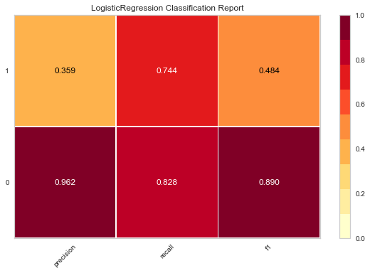

```python
# visualization of confusion matrix for tuned logistic regression model using yellowbrick package

from yellowbrick.classifier import ClassificationReport, ROCAUC
viz = ClassificationReport(bestModelLR)
viz.fit(x1_train,y1_train)
viz.score(x1_test,y1_test)
viz.show();
```

1. The visualization shows that the precision is about 36%
2. Recall is about 74%
3. Number of total people subscribing to Term Deposit is 1551
4. Number of people subscribing to the Term Deposit successfully predicted by model is 1154
5. Number of people subscribing to the Term Deposit not predicted by the model is 397 </font>

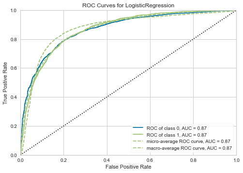

```python
# plotting new area under the curve

roc = ROCAUC(bestModelLR)
roc.fit(x1_train,y1_train)
roc.score(x1_test,y1_test)
roc.show();
```

## 3.1.3 Base Decision Tree ML Model

```python
# modeling the base decision tree

dTree = DecisionTreeClassifier(criterion='gini',random_state=1)
dTree.fit(x2_train,y2_train)
```

```
DecisionTreeClassifier(ccp_alpha=0.0, class_weight=None, criterion='gini',
                       max_depth=None, max_features=None, max_leaf_nodes=None,
                       min_impurity_decrease=0.0, min_impurity_split=None,
                       min_samples_leaf=1, min_samples_split=2,
                       min_weight_fraction_leaf=0.0, presort='deprecated',
                       random_state=1, splitter='best')
```

```python
# predict the independent variable

y2_predict = dTree.predict(x2_test)
```

#### 1. Confusion Matrix for base Decision Tree Model

```python
# print confusion matrix

cm = metrics.confusion_matrix(y2_test,y2_predict)
print(cm)
```

```
[[10981  1032]
 [  830   721]]
```

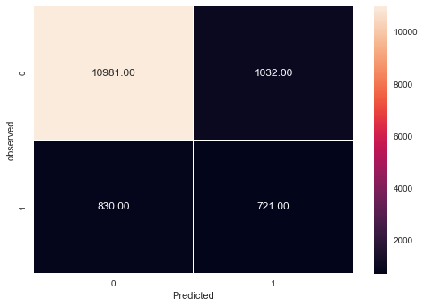

```python
# plot the confusion matrix in terms of heatmap for better visualization.
# pass parameters in draw_cm function to plot the heatmap.

draw_cm(y2_test,y2_predict)
```

```python
# True Positive (TP) = 721
# True Negative (TN) = 10981
# False Positive (FP) = 1032
# False Negative(FN) = 830
```

#### 2. Metrics for base Decision Tree Model

```python
# comparing training to testing score for decision tree model

print('Training Score:',dTree.score(x2_train,y2_train))
print('')
print('Testing Score:',dTree.score(x2_test,y2_test))
```

```
Training Score: 0.9995260214238316

Testing Score: 0.8627248599233265
```

```python
# Base Decision Tree metrics

dTree_accuracy = accuracy_score(y2_test, y2_predict)
dTree_recall = recall_score(y2_test, y2_predict)
dTree_f1 = f1_score(y2_test,y2_predict)
dTree_precision = precision_score(y2_test,y2_predict)
dTree_AUC = roc_auc_score(y2_test,y2_predict)

print('Accuracy:', dTree_accuracy)
print()
print('Recall:', dTree_recall)
print()
print('F1 Score:', dTree_f1)
print()
print('Precision:', dTree_precision)
print()
print('AUC:', dTree_AUC)
```

```
Accuracy: 0.8627248599233265

Recall: 0.46486137975499675

F1 Score: 0.4364406779661017

Precision: 0.4112949229891614

AUC: 0.6894772228001654
```

```python
# saving the metrics for base decision tree in a dataframe

dfBaseDTree = pd.DataFrame({'Model':['Decision Tree'],'Accuracy':dTree_accuracy,
                           'Recall':dTree_recall,'F1 Score':dTree_f1,
                           'Precision':dTree_precision,'AUC':dTree_AUC})

dfBaseDTree.head()
```

|  | Model | Accuracy | Recall | F1 Score | Precision | AUC |
| --- | --- | --- | --- | --- | --- | --- |
| 0 | Decision Tree | 0.862725 | 0.464861 | 0.436441 | 0.411295 | 0.689477 |

```python
# concatenate the dataframe of the decision tree model with the earlier dataframe

dfModelComparison = pd.concat([dfModelComparison,dfBaseDTree])

dfModelComparison
```

|  | Model | Accuracy | Recall | F1 Score | Precision | AUC |
| --- | --- | --- | --- | --- | --- | --- |
| 0 | Base Logistic Regression | 0.898039 | 0.284333 | 0.389404 | 0.617647 | 0.630804 |
| 0 | Tuned Logistic Regression | 0.818564 | 0.744036 | 0.483959 | 0.358608 | 0.786111 |
| 0 | Decision Tree | 0.862725 | 0.464861 | 0.436441 | 0.411295 | 0.689477 |

```python
# important features of the base decision tree

fn = x2.columns
pd.DataFrame(dTree.feature_importances_,fn).reset_index().rename(
    columns = {'index':'Feature', 0: 'Importance'}).sort_values(by='Importance', ascending=False)

# incidentally 'day' feature is of more importance and as propositioned earlier on considering it for dropping,
# infact can't be dropped
```

|  | Feature | Importance |
| --- | --- | --- |
| 0 | age | 0.166847 |
| 7 | day | 0.147650 |
| 9 | duration | 0.140151 |
| 30 | poutcome_success | 0.088289 |
| 8 | month | 0.081306 |
| 10 | campaign | 0.060230 |
| 2 | education | 0.039824 |
| 1 | marital | 0.035475 |
| 12 | previous | 0.025895 |
| 4 | balance | 0.021234 |
| 11 | pdays | 0.020594 |
| 22 | job_technician | 0.015074 |
| 14 | job_blue-collar | 0.014550 |
| 6 | loan | 0.014237 |
| 5 | housing | 0.013970 |
| 13 | job_admin. | 0.013561 |
| 17 | job_management | 0.013086 |
| 25 | contact_cellular | 0.011347 |
| 27 | contact_unknown | 0.009822 |
| 31 | poutcome_unknown | 0.009097 |
| 20 | job_services | 0.008959 |
| 28 | poutcome_failure | 0.006644 |
| 19 | job_self-employed | 0.006550 |
| 23 | job_unemployed | 0.005806 |
| 26 | contact_telephone | 0.005489 |
| 15 | job_entrepreneur | 0.005330 |
| 21 | job_student | 0.004070 |
| 29 | poutcome_other | 0.004013 |
| 18 | job_retired | 0.003929 |
| 16 | job_housemaid | 0.003556 |
| 3 | default | 0.002259 |
| 24 | job_unknown | 0.001158 |

#### 3. Visualization of Metrics for Base Decision Tree Model

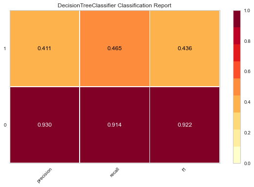

```python
# visualizing the scores of base decision tree model via yellowbricks

viz = ClassificationReport(dTree)
viz.fit(x2_train,y2_train)
viz.score(x2_test,y2_test)
viz.show();
```

1. The visualization shows that the precision is about 41%
2. Recall is about 46%
3. Number of total people subscribing to Term Deposit is 1551
4. Number of people subscribing to the Term Deposit successfully predicted by model is 721
5. Number of people subscribing to the Term Deposit not predicted by the model is 830 </font>

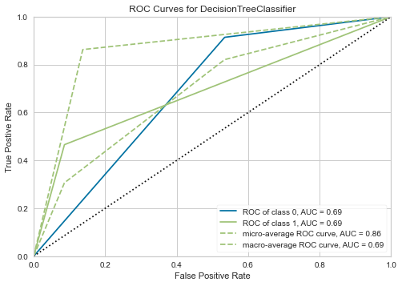

```python
# plotting area under the AUC curve

roc = ROCAUC(dTree)
roc.fit(x2_train,y2_train)
roc.score(x2_test,y2_test)
roc.show();
```

### 3.1.4 Reducing overfitting(Regularization or purning) in Decision Tree ML Model

```python
# cross validating the model

from sklearn.model_selection import cross_val_score
cv_scores = cross_val_score(DTree, x2_train, y2_train, cv=10)
cv_scores
```

```
array([0.86413902, 0.86761453, 0.86224329, 0.86224329, 0.87393365,
       0.85939968, 0.87045814, 0.85745891, 0.86599241, 0.86188369])
```

```python
# prune the decision tree

dTreeR = DecisionTreeClassifier(criterion='gini', random_state=1, max_depth = 6, min_samples_leaf = 5)

dTreeR.fit(x2_train,y2_train)
```

```
DecisionTreeClassifier(ccp_alpha=0.0, class_weight=None, criterion='gini',
                       max_depth=6, max_features=None, max_leaf_nodes=None,
                       min_impurity_decrease=0.0, min_impurity_split=None,
                       min_samples_leaf=5, min_samples_split=2,
                       min_weight_fraction_leaf=0.0, presort='deprecated',
                       random_state=1, splitter='best')
```

[output not shown]

[figure not shown]

```python
# plot the pruned decision tree

tree.plot_tree(dTreeR)
```

[figure not shown]

```python
# visualizing the pruned decision tree

from sklearn import tree

fn = x2.columns
cn = ['0','1']

fig, axes = plt.subplots(nrows =1, ncols =1, figsize =(8,2), dpi = 400)

tree.plot_tree(dTreeR, feature_names=fn, class_names=cn,filled=True)
fig.savefig('decision_tree_pruned.png')
```

```python
# predict the independent variable for the pruned decision tree

y2_predict_pruned = dTreeR.predict(x2_test)
```

#### 1. Confusion Matrix for Pruned Decision Tree Model

```python
# print confusion matrix of pruned decision tree

cm = metrics.confusion_matrix(y2_test,y2_predict_pruned)
print(cm)
```

```
[[11796   217]
 [ 1173   378]]
```

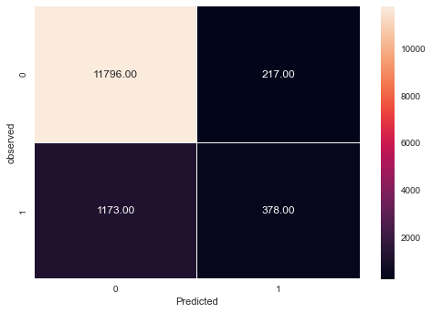

```python
# plot the confusion matrix in terms of heatmap for better visualization.
# pass parameters in draw_cm function to plot the heatmap.

draw_cm(y2_test,y2_predict_pruned)
```

```python
# True Positive (TP) = 378
# True Negative (TN) = 11796
# False Positive (FP) = 217
# False Negative(FN) = 1173
```

#### 2. Metrics for Pruned Decision Tree Model

```python
# compare the train and test data score of the pruned decision tree

print('Training Score:',dTreeR.score(x2_train,y2_train))
print('')
print('Testing Score:',dTreeR.score(x2_test,y2_test))
```

```
Training Score: 0.8999273232849875

Testing Score: 0.8975228546151578
```

```python
# Base Decision Tree metrics

dTreeR_accuracy = accuracy_score(y2_test, y2_predict_pruned)
dTreeR_recall = recall_score(y2_test, y2_predict_pruned)
dTreeR_f1 = f1_score(y2_test,y2_predict_pruned)
dTreeR_precision = precision_score(y2_test,y2_predict_pruned)
dTreeR_AUC = roc_auc_score(y2_test,y2_predict_pruned)

print('Accuracy:', dTreeR_accuracy )
print()
print('Recall:', dTreeR_recall )
print()
print('F1 Score:', dTreeR_f1)
print()
print('Precision:', dTreeR_precision)
print()
print('AUC:', dTreeR_AUC)
```

```
Accuracy: 0.8975228546151578

Recall: 0.2437137330754352

F1 Score: 0.35228331780055916

Precision: 0.6352941176470588

AUC: 0.6128249844100224
```

```python
# saving the metrics for pruned decision tree in a dataframe

dfBaseDTreeR = pd.DataFrame({'Model':['Pruned Decision Tree'],'Accuracy':dTreeR_accuracy,
                           'Recall':dTreeR_recall,'F1 Score':dTreeR_f1,
                           'Precision':dTreeR_precision,'AUC':dTreeR_AUC})

dfBaseDTreeR.head()
```

|  | Model | Accuracy | Recall | F1 Score | Precision | AUC |
| --- | --- | --- | --- | --- | --- | --- |
| 0 | Pruned Decision Tree | 0.897523 | 0.243714 | 0.352283 | 0.635294 | 0.612825 |

```python
# concatenate the dataframe of the pruned decision tree model with the earlier dataframe

dfModelComparison = pd.concat([dfModelComparison,dfBaseDTreeR])

dfModelComparison
```

|  | Model | Accuracy | Recall | F1 Score | Precision | AUC |
| --- | --- | --- | --- | --- | --- | --- |
| 0 | Base Logistic Regression | 0.898039 | 0.284333 | 0.389404 | 0.617647 | 0.630804 |
| 0 | Tuned Logistic Regression | 0.818564 | 0.744036 | 0.483959 | 0.358608 | 0.786111 |
| 0 | Decision Tree | 0.862725 | 0.464861 | 0.436441 | 0.411295 | 0.689477 |
| 0 | Pruned Decision Tree | 0.897523 | 0.243714 | 0.352283 | 0.635294 | 0.612825 |

```python
# important features of the pruned decision tree

fn = x2.columns
pd.DataFrame(dTreeR.feature_importances_,fn).reset_index().rename(
    columns = {'index':'Feature', 0: 'Importance'}).sort_values(by='Importance', ascending=False)
```

|  | Feature | Importance |
| --- | --- | --- |
| 9 | duration | 0.470124 |
| 30 | poutcome_success | 0.300746 |
| 0 | age | 0.081766 |
| 8 | month | 0.041055 |
| 5 | housing | 0.036401 |
| 27 | contact_unknown | 0.025095 |
| 7 | day | 0.011939 |
| 11 | pdays | 0.009571 |
| 1 | marital | 0.004870 |
| 10 | campaign | 0.003768 |
| 12 | previous | 0.002826 |
| 4 | balance | 0.002185 |
| 22 | job_technician | 0.001548 |
| 17 | job_management | 0.001434 |
| 6 | loan | 0.001247 |
| 28 | poutcome_failure | 0.001244 |
| 3 | default | 0.001240 |
| 13 | job_admin. | 0.000903 |
| 15 | job_entrepreneur | 0.000856 |
| 2 | education | 0.000630 |
| 25 | contact_cellular | 0.000552 |
| 24 | job_unknown | 0.000000 |
| 29 | poutcome_other | 0.000000 |
| 26 | contact_telephone | 0.000000 |
| 16 | job_housemaid | 0.000000 |
| 23 | job_unemployed | 0.000000 |
| 21 | job_student | 0.000000 |
| 20 | job_services | 0.000000 |
| 19 | job_self-employed | 0.000000 |
| 18 | job_retired | 0.000000 |
| 14 | job_blue-collar | 0.000000 |
| 31 | poutcome_unknown | 0.000000 |

#### 3. Visualization of Metrics for Pruned Decision Tree Model

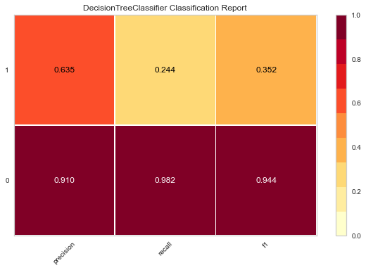

```python
# visualizing the scores of the pruned decision tree via yellowbricks

viz = ClassificationReport(dTreeR)
viz.fit(x2_train,y2_train)
viz.score(x2_test,y2_test)
viz.show();
```

1. The visualization shows that the precision is about 63%
2. Recall is about 24%
3. Number of total people subscribing to Term Deposit is 1551
4. Number of people subscribing to the Term Deposit successfully predicted by model is 378
5. Number of people subscribing to the Term Deposit not predicted by the model is 1173 </font>

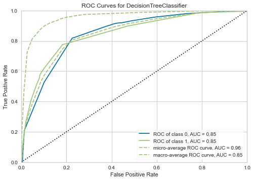

```python
# plotting area under the AUC curve

roc = ROCAUC(dTreeR)
roc.fit(x2_train,y2_train)
roc.score(x2_test,y2_test)
roc.show();
```

#### 3.2. Build the ensemble models (Bagging and Boosting) and note the model performance by using different matrices. Use same metrics as in above model. (at least 3 algorithms) (15 marks)